# Lab 1 · Auditoría: ¿qué tan fiable es lo que tengo?

Desaprendiendo sobre… Limpieza de datos · Estudiante_18 (sector Servicios)

> **Objetivo.** Antes de limpiar nada, **medir**. Pasamos los cinco ficheros por las dimensiones de calidad de la teoría (completitud, unicidad, validez, consistencia) y obtenemos un **cuadro de calidad** con semáforo. Tu trabajo: leerlo y decidir qué importa.

```r
# ── Preparación (ejecutar una vez) ───────────────────────────────────────────
# En Colab/Linux usamos binarios precompilados: los paquetes se instalan en segundos.
if (Sys.info()[["sysname"]] == "Linux")
  options(repos = c(CRAN = "https://packagemanager.posit.co/cran/__linux__/jammy/latest"))

paquetes <- c("tidyverse")
faltan <- paquetes[!vapply(paquetes, requireNamespace, logical(1), quietly = TRUE)]
if (length(faltan)) install.packages(faltan)
suppressPackageStartupMessages({
library(tidyverse)
})

# Los datos: si no están en la carpeta, se descargan
BASE_URL <- "https://raw.githubusercontent.com/vicentcorrecher/lab-limpieza-datos/main/datos"
obtener <- function(f) {
  ruta <- file.path("datos", f)
  if (!file.exists(ruta)) {
    dir.create(dirname(ruta), recursive = TRUE, showWarnings = FALSE)
    download.file(paste0(BASE_URL, "/", f), ruta, quiet = TRUE, mode = "wb")
  }
}
for (f in c(
  "funciones_labs.R",
  "estudiante_18/operaciones.csv",
  "estudiante_18/clientes.csv",
  "estudiante_18/productos_servicios.csv",
  "estudiante_18/sedes.csv",
  "estudiante_18/campanas.csv"
)) obtener(f)
source("datos/funciones_labs.R")
```

```r
d <- cargar_e18()
o <- d$operaciones
n_tab <- map_int(d, nrow)
```

## 1. Completitud: ¿falta algo?

```r
vacias <- function(x) sum(is.na(x) | (is.character(x) & str_squish(x) == ""), na.rm = TRUE)

completitud <- imap_dfr(d, \(df, tabla) tibble(
  tabla, filas = nrow(df), columnas = ncol(df),
  celdas_vacias = sum(map_int(df, vacias)),
  pct_vacias = round(100 * celdas_vacias / (filas * columnas), 3)))
completitud
```

```
# A tibble: 5 × 5
  tabla       filas columnas celdas_vacias pct_vacias
  <chr>       <int>    <int>         <int>      <dbl>
1 operaciones 19008       15           152      0.053
2 clientes     2674        7             0      0
3 productos      41        7             0      0
4 sedes           9        8             0      0
5 campanas       24        6             0      0
```

```r
# ¿En qué columnas están esas celdas vacías?
imap_dfr(d, \(df, tabla) tibble(tabla, columna = names(df), vacias = map_int(df, vacias))) |>
  filter(vacias > 0)
```

```
# A tibble: 1 × 3
  tabla       columna      vacias
  <chr>       <chr>         <int>
1 operaciones satisfaccion    152
```

## 2. Unicidad: ¿cada cosa aparece una sola vez?

```r
claves <- c(operaciones = "operacion_id", clientes = "cliente_id", productos = "producto_id",
            sedes = "sede_id", campanas = "campana_id")

unicidad <- imap_dfr(d, \(df, tabla) tibble(
  tabla, clave = claves[[tabla]], filas = nrow(df),
  claves_distintas = n_distinct(df[[claves[[tabla]]]]),
  filas_repetidas = filas - claves_distintas,
  filas_identicas = sum(duplicated(df))))
unicidad
```

```
# A tibble: 5 × 6
  tabla       clave       filas claves_distintas filas_repetidas filas_identicas
  <chr>       <chr>       <int>            <int>           <int>           <int>
1 operaciones operacion_… 19008            19000               8               8
2 clientes    cliente_id   2674             2674               0               0
3 productos   producto_id    41               41               0               0
4 sedes       sede_id         9                9               0               0
5 campanas    campana_id     24               24               0               0
```

## 3. Validez: ¿cumple las reglas del negocio?

Escribimos las reglas **por escrito** (no «de memoria») y contamos cuántas filas las incumplen.

```r
alta_ini <- as.Date("2022-01-01"); alta_fin <- as.Date("2025-12-31")
c_ <- d$clientes; p_ <- d$productos; s_ <- d$sedes; k_ <- d$campanas

regla <- function(tabla, texto, incumplen) tibble(tabla, comprobacion = texto, incumplen = as.integer(incumplen), base = n_tab[[tabla]])

validez <- bind_rows(
  regla("operaciones", "unidades >= 1",                           sum(o$unidades < 1)),
  regla("operaciones", "precio_unitario > 0",                     sum(o$precio_unitario <= 0)),
  regla("operaciones", "descuento entre 0 y 1",                   sum(o$descuento_pct < 0 | o$descuento_pct > 1)),
  regla("operaciones", "satisfacción entre 1 y 10 (si existe)",   sum(o$satisfaccion < 1 | o$satisfaccion > 10, na.rm = TRUE)),
  regla("operaciones", "fecha dentro del periodo 2022-2025",      sum(o$fecha < alta_ini | o$fecha > alta_fin)),
  regla("operaciones", "margen = ingresos - coste",               sum(abs(o$margen - (o$ingresos - o$coste)) > 0.02)),
  regla("operaciones", "ingresos = unidades x precio x (1-dto)",  sum(abs(o$ingresos - o$unidades * o$precio_unitario * (1 - o$descuento_pct)) > 0.05 * o$unidades)),
  regla("operaciones", "duración > 0",                            sum(o$duracion_min <= 0)),
  regla("clientes",    "fecha_alta no futura",                    sum(c_$fecha_alta > alta_fin)),
  regla("productos",   "precio_lista > coste_unitario",           sum(p_$precio_lista <= p_$coste_unitario)),
  regla("sedes",       "coordenadas dentro de España peninsular", sum(s_$latitud < 35 | s_$latitud > 44 | s_$longitud < -10 | s_$longitud > 5)),
  regla("campanas",    "fecha_fin >= fecha_inicio",               sum(k_$fecha_fin < k_$fecha_inicio)),
  regla("campanas",    "inversion > 0",                           sum(k_$inversion <= 0)))
validez
```

```
# A tibble: 13 × 4
   tabla       comprobacion                            incumplen  base
   <chr>       <chr>                                       <int> <int>
 1 operaciones unidades >= 1                                   0 19008
 2 operaciones precio_unitario > 0                             0 19008
 3 operaciones descuento entre 0 y 1                           0 19008
 4 operaciones satisfacción entre 1 y 10 (si existe)           0 19008
 5 operaciones fecha dentro del periodo 2022-2025              0 19008
 6 operaciones margen = ingresos - coste                       0 19008
 7 operaciones ingresos = unidades x precio x (1-dto)          0 19008
 8 operaciones duración > 0                                    0 19008
 9 clientes    fecha_alta no futura                            0  2674
10 productos   precio_lista > coste_unitario                   0    41
11 sedes       coordenadas dentro de España peninsular         0     9
12 campanas    fecha_fin >= fecha_inicio                       0    24
13 campanas    inversion > 0                                   0    24
```

## 4. Consistencia: ¿cuadra entre tablas y dentro de cada columna?

**4.1 Integridad referencial** (¿hay operaciones que apuntan a un cliente, producto o sede que no existe?)

```r
huerfanas <- tribble(
  ~relacion, ~operaciones_huerfanas,
  "operaciones.cliente_id  -> clientes",  nrow(anti_join(o, d$clientes,  by = "cliente_id")),
  "operaciones.producto_id -> productos", nrow(anti_join(o, d$productos, by = "producto_id")),
  "operaciones.sede_id     -> sedes",     nrow(anti_join(o, d$sedes,     by = "sede_id")))
huerfanas
```

```
# A tibble: 3 × 2
  relacion                             operaciones_huerfanas
  <chr>                                                <int>
1 operaciones.cliente_id  -> clientes                      0
2 operaciones.producto_id -> productos                     0
3 operaciones.sede_id     -> sedes                         0
```

**4.2 Categorías escritas de forma distinta** (misma cosa, distinto texto: «web» y «Web »)

```r
# filas que usan una grafía minoritaria de un valor que, normalizado, es el mismo
filas_en_variantes <- function(x) {
  tibble(x = x[!is.na(x)]) |>
    mutate(k = str_to_lower(str_squish(x))) |>
    count(k, x) |> group_by(k) |> filter(n() > 1) |>
    summarise(extra = sum(n) - max(n)) |> pull(extra) |> sum()
}

texto <- imap_dfr(d, \(df, tabla) df |>
  select(where(is.character), -ends_with("_id")) |>
  summarise(across(everything(), filas_en_variantes)) |>
  pivot_longer(everything(), names_to = "columna", values_to = "filas_afectadas") |>
  mutate(tabla = tabla)) |>
  filter(filas_afectadas > 0)
texto
```

```
# A tibble: 1 × 3
  columna    filas_afectadas tabla
  <chr>                <dbl> <chr>
1 canal_alta              27 clientes
```

```r
d$clientes |> count(canal_alta, sort = TRUE)   # aquí se ve el culpable
```

```
# A tibble: 5 × 2
  canal_alta     n
  <chr>      <int>
1 presencial   904
2 web          880
3 app          602
4 referido     261
5 Web           27
```

**4.3 Coherencia en el tiempo** (una operación no debería ocurrir antes de que exista el cliente, el producto o la sede)

```r
oj <- o |>
  left_join(select(d$clientes,  cliente_id, fecha_alta),        by = "cliente_id") |>
  left_join(select(d$productos, producto_id, fecha_lanzamiento), by = "producto_id") |>
  left_join(select(d$sedes,     sede_id, fecha_apertura),        by = "sede_id")

temporal <- bind_rows(
  regla("operaciones", "operación anterior al alta del cliente",        sum(oj$fecha < oj$fecha_alta)),
  regla("operaciones", "operación anterior al lanzamiento del servicio", sum(oj$fecha < oj$fecha_lanzamiento)),
  regla("operaciones", "operación anterior a la apertura de la sede",    sum(oj$fecha < oj$fecha_apertura)))
temporal
```

```
# A tibble: 3 × 4
  tabla       comprobacion                                   incumplen  base
  <chr>       <chr>                                              <int> <int>
1 operaciones operación anterior al alta del cliente              1960 19008
2 operaciones operación anterior al lanzamiento del servicio      1346 19008
3 operaciones operación anterior a la apertura de la sede            0 19008
```

## 5. El cuadro de calidad

Juntamos todo en una sola tabla. El **semáforo** lo decides tú con dos umbrales.

```r
# >>> TOCA AQUÍ: cambia los umbrales y vuelve a ejecutar la celda <<<
UMBRAL_ROJO <- 1       # % de filas afectadas a partir del cual es rojo
# (verde = 0 incumplimientos; ámbar = hay incumplimientos pero por debajo del umbral rojo)

cuadro <- bind_rows(
  completitud |> transmute(dimension = "Completitud", tabla, comprobacion = "celdas vacías", incumplen = celdas_vacias, base = filas * columnas),
  unicidad    |> transmute(dimension = "Unicidad", tabla, comprobacion = "claves repetidas", incumplen = filas_repetidas, base = filas),
  validez     |> mutate(dimension = "Validez"),
  huerfanas   |> transmute(dimension = "Consistencia", tabla = "operaciones", comprobacion = relacion, incumplen = operaciones_huerfanas, base = n_tab[["operaciones"]]),
  texto       |> transmute(dimension = "Consistencia", tabla, comprobacion = paste("grafías distintas en", columna), incumplen = filas_afectadas, base = n_tab[tabla]),
  temporal    |> mutate(dimension = "Consistencia")) |>
  mutate(pct = round(100 * incumplen / base, 3),
         semaforo = case_when(incumplen == 0 ~ "verde", pct < UMBRAL_ROJO ~ "ámbar", TRUE ~ "rojo"))

cuadro |> filter(semaforo != "verde") |> arrange(desc(pct)) |> select(dimension, tabla, comprobacion, incumplen, pct, semaforo)
```

```
# A tibble: 5 × 6
  dimension    tabla       comprobacion                incumplen    pct semaforo
  <chr>        <chr>       <chr>                           <dbl>  <dbl> <chr>
1 Consistencia operaciones operación anterior al alta…      1960 10.3   rojo
2 Consistencia operaciones operación anterior al lanz…      1346  7.08  rojo
3 Consistencia clientes    grafías distintas en canal…        27  1.01  rojo
4 Completitud  operaciones celdas vacías                     152  0.053 ámbar
5 Unicidad     operaciones claves repetidas                    8  0.042 ámbar
```

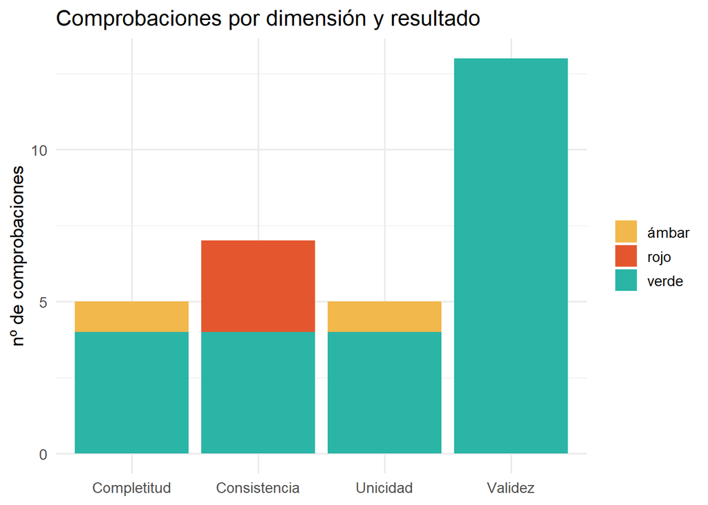

```r
cuadro |> count(dimension, semaforo) |>
  ggplot(aes(dimension, n, fill = semaforo)) +
  geom_col() +
  scale_fill_manual(values = c(verde = "#2BB5A6", `ámbar` = "#F2B84B", rojo = "#E4572E")) +
  labs(title = "Comprobaciones por dimensión y resultado", x = NULL, y = "nº de comprobaciones", fill = NULL) +
  theme_minimal(base_size = 13)
```

### Para pensar

> 1. ¿Qué dimensión falla más? ¿Es **la que más importa** para calcular ingresos, margen o satisfacción?
> 2. Hay problemas en **rojo** que no son errores de tecleo sino de **proceso** (fechas que no cuadran entre tablas). ¿Quién en la empresa podría explicarlos?
> 3. Las filas duplicadas son solo 8 en 19.000. ¿Merece la pena arreglarlas? ¿Y si cada una fuera un pedido de 50.000 €?
> 4. Todas las claves y todos los `JOIN` están perfectos. ¿Significa eso que los **datos** están bien?

### Toca esto

Sube `UMBRAL_ROJO` a 5 y ejecuta de nuevo. ¿Qué problemas pasan de rojo a ámbar? ¿Estás de acuerdo con el semáforo resultante? **El umbral es una decisión de negocio, no técnica.**